# ML & Hypothesis Tests

Here is the completed data set:

```r
mydat = read.csv("~/Desktop/data_out.csv")%>%
  filter(threshold == 250 & winds == 2)%>%
  select(-winds, - threshold, -index)
mydat%>%
  filter(complete.cases(.))%>%
  summary()
```

```
       ID                         when                     Event
 Min.   :201.0   2017-08-31 20:52:42:  2   2017-08-31 20:52:42:  2
 1st Qu.:215.0   2017-09-09 23:33:52:  2   2017-09-09 23:33:52:  2
 Median :219.0   2017-09-27 20:55:42:  2   2017-09-27 20:55:42:  2
 Mean   :217.4   2017-11-23 23:48:52:  2   2017-11-23 23:48:52:  2
 3rd Qu.:222.0   2017-01-19 19:42:22:  1   2017-01-19 19:42:22:  1
 Max.   :228.0   2017-01-21 01:58:09:  1   2017-01-21 01:58:09:  1
                 (Other)            :132   (Other)            :132
     Stress            Y            SDNN            SDANN
 Min.   :1.000   Control:123   Min.   : 24.72   Min.   :  0.6012
 1st Qu.:2.000   Episode: 19   1st Qu.: 40.48   1st Qu.:  6.8446
 Median :2.000                 Median : 49.09   Median : 11.2996
 Mean   :2.549                 Mean   : 53.14   Mean   : 15.2656
 3rd Qu.:3.000                 3rd Qu.: 57.55   3rd Qu.: 19.3051
 Max.   :5.000                 Max.   :130.25   Max.   :141.0248

    SDNNIDX          pNN50             SDSD            rMSSD
 Min.   :23.91   Min.   : 2.003   Min.   : 22.91   Min.   : 22.90
 1st Qu.:34.01   1st Qu.:12.428   1st Qu.: 38.97   1st Qu.: 38.95
 Median :43.03   Median :19.209   Median : 47.99   Median : 47.97
 Mean   :44.01   Mean   :19.934   Mean   : 48.66   Mean   : 48.64
 3rd Qu.:49.55   3rd Qu.:26.197   3rd Qu.: 56.11   3rd Qu.: 56.08
 Max.   :86.52   Max.   :67.879   Max.   :113.96   Max.   :113.92

      IRRR            MADRR            TINN             HRVi
 Min.   : 31.25   Min.   :15.63   Min.   : 62.34   Min.   : 3.990
 1st Qu.: 46.88   1st Qu.:15.63   1st Qu.: 90.20   1st Qu.: 5.773
 Median : 62.50   Median :31.25   Median :105.40   Median : 6.745
 Mean   : 65.36   Mean   :26.41   Mean   :112.25   Mean   : 7.184
 3rd Qu.: 62.50   3rd Qu.:31.25   3rd Qu.:129.03   3rd Qu.: 8.258
 Max.   :203.13   Max.   :93.75   Max.   :215.79   Max.   :13.811
```

# What is the distribution of stress for the usable surveys?

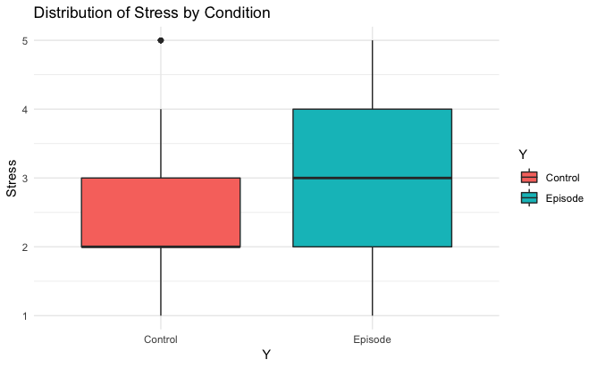

Episodes may have higher stress levels than controls. We will remove the stressed out outliers for analysis. We will also do within participant z-score centering, like so:

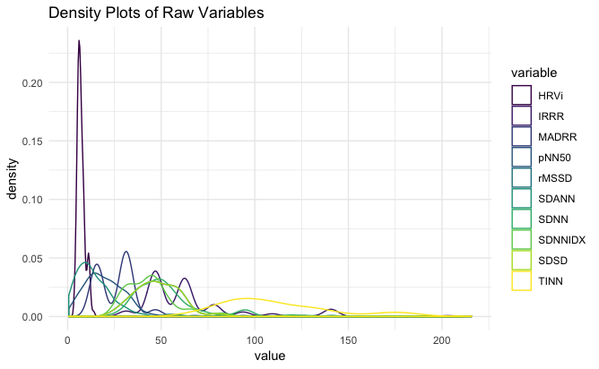

```r
#variable distribution without z-score scaling
mydat%>%
  filter(complete.cases(.))%>%
  filter(!(Stress > 4 & Y == "Control"))%>%
  select(ID, Y:HRVi)%>%
  # group_by(ID)%>%
  # mutate_at(.vars = vars(SDNN:HRVi), funs(scale))%>%
  # ungroup()%>%
  filter(complete.cases(.))%>%
  gather("variable", "value", SDNN:HRVi)%>%
  ggplot(aes(value, color = variable))+
  geom_density(alpha = 0.5)+
  theme_minimal()+
  scale_color_viridis(discrete = TRUE)+
  labs(title = "Density Plots of Raw Variables")
```

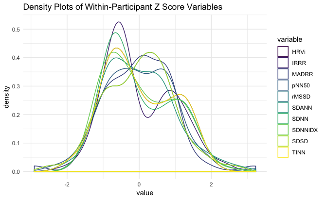

```r
#variable distribution with z-score scaling
mydat%>%
  filter(complete.cases(.))%>%
  filter(!(Stress > 4 & Y == "Control"))%>% #filter high stress
  select(ID, Y:HRVi)%>%
  group_by(ID)%>%
  mutate_at(.vars = vars(SDNN:HRVi), funs(scale))%>% #z score transform within-subject
  ungroup()%>%
  filter(complete.cases(.))%>%
  gather("variable", "value", SDNN:HRVi)%>%
  ggplot(aes(value, color = variable))+
  geom_density(alpha = 0.5)+
  theme_minimal()+
  scale_color_viridis(discrete = TRUE)+
  labs(title = "Density Plots of Within-Participant Z Score Variables")
```

# Do features differ statistically by group?

What are the mean values for each of the variables by condition?

```r
mydat%>%
  filter(complete.cases(.))%>%
  filter(!(Stress > 4 & Y == "Control"))%>% #filter high stress
  select(ID, Y:HRVi)%>%
  group_by(ID)%>%
  mutate_at(.vars = vars(SDNN:HRVi), funs(scale))%>% #z score transform
  ungroup()%>%
  filter(complete.cases(.))%>%
  select(Y:HRVi)%>%
  group_by(Y)%>%
  summarise_at(.vars = vars(SDNN:HRVi), funs(mean(.)))
```

| Y | SDNN | SDANN | SDNNIDX | pNN50 | SDSD | rMSSD | IRRR | MADRR | TINN | HRVi |
| --- | --- | --- | --- | --- | --- | --- | --- | --- | --- | --- |
| Control | -0.01995289 | 0.00839158 | -0.04696531 | -0.0003382092 | 0.01154354 | 0.01154672 | -0.0376267 | 0.001773003 | -0.04322148 | -0.04322148 |
| Episode | 0.11236629 | -0.04725785 | 0.26448883 | 0.0019046516 | -0.06500836 | -0.06502626 | 0.2118977 | -0.009984806 | 0.24340519 | 0.24340519 |

Note that we now have 126 usable cases as the Z-scoring process removed participants with 1 survey or with uniform values for all their surveys.

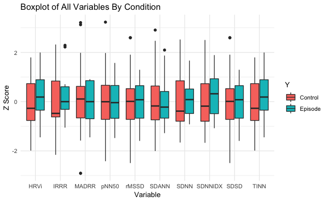

```r
mydat%>%
  filter(complete.cases(.))%>%
  filter(!(Stress > 4 & Y == "Control"))%>% #filter high stress
  select(ID, Y:HRVi)%>%
  group_by(ID)%>%
  mutate_at(.vars = vars(SDNN:HRVi), funs(scale))%>% #z score transform
  ungroup()%>%
  filter(complete.cases(.))%>%
  select(Y:HRVi)%>%
  gather("Variable", "Value", 2:11)%>%
  ggplot(aes(x=Variable, y=Value))+
  geom_boxplot(aes(fill=Y))+
  theme_minimal()+
  labs(y = "Z Score", title = "Boxplot of All Variables By Condition")
```

Are there differences using a regular T-Test? The table below shows $p$-values at each variable’s comparison:

```r
mydat%>%
  filter(complete.cases(.))%>%
  filter(!(Stress > 4 & Y == "Control"))%>% #filter high stress
  select(ID, Y:HRVi)%>%
  group_by(ID)%>%
  mutate_at(.vars = vars(SDNN:HRVi), funs(scale))%>% #z score transform
  ungroup()%>%
  filter(complete.cases(.))%>%
  select(Y:HRVi)%>%
  summarise_at(funs(t.test(x = .[Y == "Control"],
                           y = .[Y != "Control"])$p.value),
               .vars = vars(SDNN:HRVi))
```

| SDNN | SDANN | SDNNIDX | pNN50 | SDSD | rMSSD | IRRR | MADRR | TINN | HRVi |
| --- | --- | --- | --- | --- | --- | --- | --- | --- | --- |
| 0.4989254 | 0.8127643 | 0.2095735 | 0.9921406 | 0.7276959 | 0.7276155 | 0.2859083 | 0.9564277 | 0.2102175 | 0.2102175 |

Another approach using instead, the permuation T-test, gives us $p$-values too:

```r
mydat%>%
  filter(complete.cases(.))%>%
  filter(!(Stress > 4 & Y == "Control"))%>% #filter high stress
  select(ID, Y:HRVi)%>%
  group_by(ID)%>%
  mutate_at(.vars = vars(SDNN:HRVi), funs(scale))%>% #z score transform
  ungroup()%>%
  filter(complete.cases(.))%>%
  select(Y:HRVi)%>%
  summarise_at(funs(twotPermutation(.[Y == "Control"],
                                    .[Y != "Control"],
                                    plotit = F)),
               .vars = vars(SDNN:HRVi))
```

| SDNN | SDANN | SDNNIDX | pNN50 | SDSD | rMSSD | IRRR | MADRR | TINN | HRVi |
| --- | --- | --- | --- | --- | --- | --- | --- | --- | --- |
| 0.555 | 0.802 | 0.172 | 0.99 | 0.753 | 0.76 | 0.276 | 0.962 | 0.214 | 0.228 |

It seems like none of the variables are statistically different.

# Predicting Condition

We use simple over- and under-sampling as well as ROSE and SMOTE to deal with the class imbalance problem.

```r
# Here we set the train and test set
set.seed(2)
mydat2 = mydat%>%
  filter(complete.cases(.))%>%
  filter(!(Stress > 4 & Y == "Control"))%>% #filter high stress
  select(ID, Y:HRVi)%>%
  group_by(ID)%>%
  mutate_at(.vars = vars(SDNN:HRVi), funs(scale))%>% #z score transform
  ungroup()%>%
  filter(complete.cases(.))%>%
  select(Y:HRVi)%>%
  rename(Class = Y)
train = createDataPartition(y = mydat2$Class, p = 0.7, list = FALSE)
# next, we resample from the training set with different methods
down = downSample(select(mydat2, -Class)[train,], mydat2$Class[train])
up = upSample(select(mydat2, -Class)[train,], mydat2$Class[train])
smote = SMOTE(Class ~ ., data  = as.data.frame(mydat2[train,]))
rose = ROSE(Class ~ ., data  = mydat2[train,])$data
#some indices for loops
sample_Names = c("None", "DownSample", "UpSample", "SMOTE", "ROSE")
samples = list(mydat2[train,], down, up, smote, rose)
names(samples) = sample_Names
```

## Logistic Regression/GLM

Fitting a glm and inspecting the model fit:

```r
#empty vectors for sampling methods
glmFitSummaries = vector("list")
glmModels = vector("list")
#loop through the different samples and fit the model for each
#store results in empty vectors
for(s in 1:length(samples)){
  print(names(samples)[[s]])

  glmModels[[names(samples)[s]]] = train(Class ~.,
                 method = "glm",
                 family=binomial,
                 data=samples[[s]])

  #collect variable significance metrics
  glmFitSummaries[[names(samples)[s]]] = summary(glmModels[[names(samples)[s]]]$finalModel)%>%
    .$coefficients%>%
    data.frame()%>%
    as.tibble()%>%
    rownames_to_column(var = "Variable")%>%
    rename(P_Value = Pr...z..,
           Z_Value = z.value,
           Std_Error = Std..Error)%>%
    mutate(Significant = ifelse(P_Value < 0.05, "Significant", "Not Significant"),
           Sampling = names(samples)[[s]])
}
```

```
[1] "None"
[1] "DownSample"
[1] "UpSample"
[1] "SMOTE"
[1] "ROSE"
```

```r
#print the GLM variable estimates and significance for each model
do.call(rbind, glmFitSummaries)%>%
  select(Sampling, Variable, Significant, everything())
```

|  | Sampling | Variable | Significant | Estimate | Std_Error | Z_Value | P_Value |
| --- | --- | --- | --- | --- | --- | --- | --- |
| 1 | None | (Intercept) | Significant | -1.850834e+00 | 0.3431330 | -5.39392612 | 6.893457e-08 |
| 2 | None | SDNN | Not Significant | -5.013109e-01 | 0.8692430 | -0.57672117 | 5.641278e-01 |
| 3 | None | SDANN | Not Significant | -2.932526e-01 | 0.4110679 | -0.71339216 | 4.756031e-01 |
| 4 | None | SDNNIDX | Not Significant | 1.536113e+00 | 0.9141159 | 1.68043547 | 9.287262e-02 |
| 5 | None | pNN50 | Not Significant | 1.680865e+00 | 1.5590223 | 1.07815323 | 2.809654e-01 |
| 6 | None | SDSD | Not Significant | 6.567492e+02 | 896.8251278 | 0.73230464 | 4.639826e-01 |
| 7 | None | rMSSD | Not Significant | -6.583327e+02 | 896.9996880 | -0.73392741 | 4.629930e-01 |
| 8 | None | IRRR | Not Significant | -7.447557e-01 | 0.9593842 | -0.77628518 | 4.375806e-01 |
| 9 | None | MADRR | Not Significant | -7.993813e-01 | 0.7032099 | -1.13676051 | 2.556384e-01 |
| 10 | None | TINN | Not Significant | 3.116981e-01 | 0.9625820 | 0.32381461 | 7.460784e-01 |

[output cut: 41 more lines]

SMOTE resampling produced the highest number of significant predictors.

Evaluating prediction:

```r
#empy vectors for results
glmResults = vector("list")
glmPredictions = vector("list")
#loop through the different samples and predict test cases
#store results in empty vectors
for(s in 1:length(samples)){
  print(names(samples)[[s]])

  pred = predict(
    glmModels[[names(samples)[s]]],
    newdata = mydat2[-train,],
    type = "raw")%>%
    data.frame(pred = ., obs = mydat2$Class[-train])

  glmPredictions[[names(samples)[s]]] = pred

  glmResults[[names(samples)[s]]] = confusionMatrix(pred$pred,
                                                    pred$obs,
                                                    positive = "Episode")
}
```

```
[1] "None"
```

```
prediction from a rank-deficient fit may be misleading
```

```
[1] "DownSample"
```

```
prediction from a rank-deficient fit may be misleading
```

```
[1] "UpSample"
```

```
prediction from a rank-deficient fit may be misleading
```

```
[1] "SMOTE"
```

```
prediction from a rank-deficient fit may be misleading
```

```
[1] "ROSE"
```

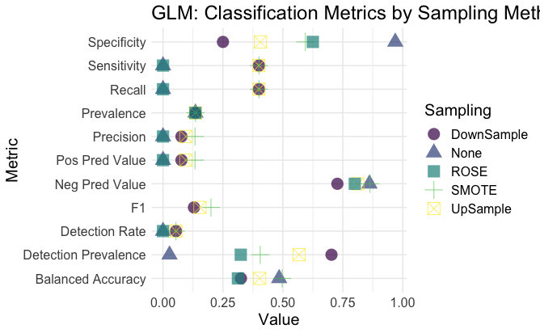

```r
#data frame for compiling results
comparisons = data.frame()
#loop through each sampling method's results and compile
for(x in 1:length(glmResults)){

  comparisons = glmResults[[names(samples)[x]]]$byClass%>%
    data.frame(Value = .)%>%
    rownames_to_column()%>%
    rename(Variable = rowname)%>%
    mutate(Sampling = names(samples)[x])%>%
    select(Sampling, everything())%>%
    rbind(comparisons, .)
}
#plot
comparisons%>%
  ggplot(aes(x = Variable, y = Value))+
  geom_point(aes(color = Sampling, shape = Sampling), alpha = 0.7, size = 5)+
  theme_minimal()+
  labs(title = "GLM: Classification Metrics by Sampling Method", x = "Metric")+
  coord_flip()+
  theme(text = element_text(size = 15))+
  scale_color_viridis(discrete = TRUE)
```

## Results

```r
lapply(glmPredictions, table)
```

```
$None
         obs
pred      Control Episode
  Control      31       5
  Episode       1       0

$DownSample
         obs
pred      Control Episode
  Control       8       3
  Episode      24       2

$UpSample
         obs
pred      Control Episode
  Control      13       3
  Episode      19       2

$SMOTE
         obs
pred      Control Episode
  Control      19       3
  Episode      13       2

$ROSE
         obs
pred      Control Episode
  Control      20       5
  Episode      12       0
```

```r
do.call(rbind, glmPredictions)%>%
  rownames_to_column()%>%
  rename(S = rowname)%>%
  separate(S, c("Sampling", "xx"), sep = "\\.")%>%
  select(-xx)%>%
  group_by(Sampling)%>%
  summarise(Overall_Accuracy = sum(pred == obs)/n())%>%
  arrange(desc(Overall_Accuracy))
```

| Sampling | Overall_Accuracy |
| --- | --- |
| None | 0.8378378 |
| SMOTE | 0.5675676 |
| ROSE | 0.5405405 |
| UpSample | 0.4054054 |
| DownSample | 0.2702703 |

```r
final_glm = comparisons%>%
  filter(Sampling == "SMOTE")%>%
  arrange(Variable)%>%
  mutate(Model = "LogisticRegression")%>%
  select(Model, everything())
final_glm
```

| Model | Sampling | Variable | Value |
| --- | --- | --- | --- |
| LogisticRegression | SMOTE | Balanced Accuracy | 0.49687500 |
| LogisticRegression | SMOTE | Detection Prevalence | 0.40540541 |
| LogisticRegression | SMOTE | Detection Rate | 0.05405405 |
| LogisticRegression | SMOTE | F1 | 0.20000000 |
| LogisticRegression | SMOTE | Neg Pred Value | 0.86363636 |
| LogisticRegression | SMOTE | Pos Pred Value | 0.13333333 |
| LogisticRegression | SMOTE | Precision | 0.13333333 |
| LogisticRegression | SMOTE | Prevalence | 0.13513514 |
| LogisticRegression | SMOTE | Recall | 0.40000000 |
| LogisticRegression | SMOTE | Sensitivity | 0.40000000 |

[output cut: 1 more lines]

## RandomForest

Fitting a random forest model for each resampling method:

```
[1] "None"
```

```
There were missing values in resampled performance measures.
```

```
[1] "DownSample"
```

```
There were missing values in resampled performance measures.
```

```
[1] "UpSample"
```

```
There were missing values in resampled performance measures.
```

```
[1] "SMOTE"
```

```
There were missing values in resampled performance measures.
```

```
[1] "ROSE"
```

```
There were missing values in resampled performance measures.
```

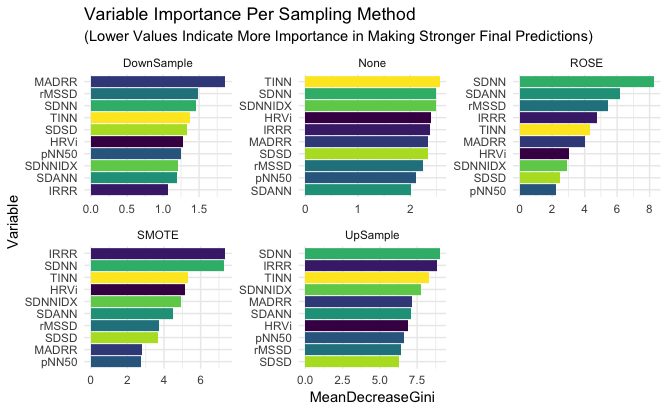

```r
# plotting solution found here:
# https://github.com/dgrtwo/drlib/blob/master/R/reorder_within.R
# Much appreciated @drlib
reorder_within <- function(x, by, within, fun = mean, sep = "___", ...) {
  new_x <- paste(x, within, sep = sep)
  stats::reorder(new_x, by, FUN = fun)
}
scale_x_reordered <- function(..., sep = "___") {
  reg <- paste0(sep, ".+$")
  ggplot2::scale_x_discrete(labels = function(x) gsub(reg, "", x), ...)
}
scale_y_reordered <- function(..., sep = "___") {
  reg <- paste0(sep, ".+$")
  ggplot2::scale_y_discrete(labels = function(x) gsub(reg, "", x), ...)
}
do.call(rbind, rfFitSummaries)%>%
  mutate_if(is.character, as.factor)%>%
  ggplot(., aes(x = reorder_within(Variable, MeanDecreaseGini, Sampling),
                y = MeanDecreaseGini,
                fill = Variable))+
  geom_bar(stat = "identity", show.legend = FALSE)+
  scale_x_reordered()+
  facet_wrap(~Sampling, scales = "free")+
  coord_flip()+
  labs(x="Variable",
       title = "Variable Importance Per Sampling Method",
       subtitle = "(Lower Values Indicate More Importance in Making Stronger Final Predictions)")+
  theme_minimal()+
  scale_fill_viridis(discrete=TRUE)
```

Using random forest the most important variable for prediction varies with the resampling approach, so it’s hard to tell what’s being said here.

Evaluating prediction:

```r
#empy vectors for results
rfResults = vector("list")
rfPredictions = vector("list")
#loop through the different samples and predict test cases
#store results in empty vectors
for(s in 1:length(samples)){
  print(names(samples)[[s]])

  rfPredictions[[names(samples)[s]]] = predict(rfModels[[names(samples)[s]]],newdata=mydat2[-train,])%>%
  tibble(pred = ., obs = mydat2[-train,]$Class)

  rfResults[[names(samples)[s]]] = confusionMatrix(pred$pred,
                                                    pred$obs,
                                                    positive = "Episode")
}
```

```
[1] "None"
[1] "DownSample"
[1] "UpSample"
[1] "SMOTE"
[1] "ROSE"
```

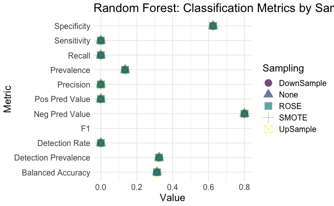

```r
#data frame for compiling results
comparisons = data.frame()
#loop through each sampling method's results and compile
for(x in 1:length(glmResults)){

  comparisons = rfResults[[names(samples)[x]]]$byClass%>%
    data.frame(Value = .)%>%
    rownames_to_column()%>%
    rename(Variable = rowname)%>%
    mutate(Sampling = names(samples)[x])%>%
    select(Sampling, everything())%>%
    rbind(comparisons, .)
}
#plot
comparisons%>%
  ggplot(aes(x = Variable, y = Value))+
  geom_point(aes(color = Sampling, shape = Sampling), alpha = 0.7, size = 5)+
  theme_minimal()+
  labs(title = "Random Forest: Classification Metrics by Sampling Method",
       x = "Metric")+
  coord_flip()+
  theme(text = element_text(size = 15))+
  scale_color_viridis(discrete = TRUE)
```

## Results

```r
lapply(rfPredictions, table)
```

```
$None
         obs
pred      Control Episode
  Control      30       5
  Episode       2       0

$DownSample
         obs
pred      Control Episode
  Control      13       3
  Episode      19       2

$UpSample
         obs
pred      Control Episode
  Control      26       5
  Episode       6       0

$SMOTE
         obs
pred      Control Episode
  Control      22       4
  Episode      10       1

$ROSE
         obs
pred      Control Episode
  Control      23       4
  Episode       9       1
```

```r
do.call(rbind, rfPredictions)%>%
  rownames_to_column()%>%
  rename(S = rowname)%>%
  separate(S, c("Sampling", "xx"), sep = "\\.")%>%
  select(-xx)%>%
  group_by(Sampling)%>%
  summarise(Overall_Accuracy = sum(pred == obs)/n())%>%
  arrange(desc(Overall_Accuracy))
```

| Sampling | Overall_Accuracy |
| --- | --- |
| None | 0.8108108 |
| UpSample | 0.7027027 |
| ROSE | 0.6486486 |
| SMOTE | 0.6216216 |
| DownSample | 0.4054054 |

```r
final_RF
```

| Model | Sampling | Variable | Value |
| --- | --- | --- | --- |
| RandomForest | None | Balanced Accuracy | 0.3125000 |
| RandomForest | None | Detection Prevalence | 0.3243243 |
| RandomForest | None | Detection Rate | 0.0000000 |
| RandomForest | None | F1 | NaN |
| RandomForest | None | Neg Pred Value | 0.8000000 |
| RandomForest | None | Pos Pred Value | 0.0000000 |
| RandomForest | None | Precision | 0.0000000 |
| RandomForest | None | Prevalence | 0.1351351 |
| RandomForest | None | Recall | 0.0000000 |
| RandomForest | None | Sensitivity | 0.0000000 |

[output cut: 1 more lines]

## Support Vector Machine

Fitting and inspecting the model:

```r
svmFitSummaries
```

```
$None

Call:
svm.default(x = as.matrix(x), y = y, kernel = "linear", cost = param$cost,
    probability = classProbs)


Parameters:
   SVM-Type:  C-classification
 SVM-Kernel:  linear
       cost:  0.07881408
      gamma:  0.1

Number of Support Vectors:  39

 ( 25 14 )


Number of Classes:  2

Levels:
 Control Episode




$DownSample

Call:
svm.default(x = as.matrix(x), y = y, kernel = "linear", cost = param$cost,
    probability = classProbs)


Parameters:
   SVM-Type:  C-classification
 SVM-Kernel:  linear
       cost:  1.415919
      gamma:  0.1

Number of Support Vectors:  21
```

[output cut: 71 more lines]

```
Parameters:
   SVM-Type:  C-classification
 SVM-Kernel:  linear
       cost:  0.06819289
      gamma:  0.1

Number of Support Vectors:  80

 ( 40 40 )


Number of Classes:  2

Levels:
 Control Episode
```

Not much to interpret from the summaries.

Evaluating prediction:

```r
#empy vectors for results
svmResults = vector("list")
svmPredictions = vector("list")
#loop through the different samples and predict test cases
#store results in empty vectors
for(s in 1:length(samples)){
  print(names(samples)[[s]])

  svmPredictions[[names(samples)[s]]] = predict(svmModels[[names(samples)[s]]],newdata=mydat2[-train,])%>%
  tibble(pred = ., obs = mydat2[-train,]$Class)

  svmResults[[names(samples)[s]]] = confusionMatrix(pred$pred,
                                                    pred$obs,
                                                    positive = "Episode")
}
```

```
[1] "None"
[1] "DownSample"
[1] "UpSample"
[1] "SMOTE"
[1] "ROSE"
```

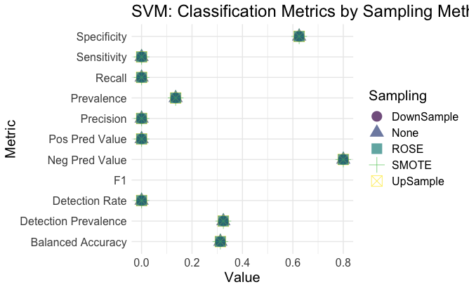

```r
#data frame for compiling results
comparisons = data.frame()
#loop through each sampling method's results and compile
for(x in 1:length(svmResults)){

  comparisons = svmResults[[names(samples)[x]]]$byClass%>%
    data.frame(Value = .)%>%
    rownames_to_column()%>%
    rename(Variable = rowname)%>%
    mutate(Sampling = names(samples)[x])%>%
    select(Sampling, everything())%>%
    rbind(comparisons, .)
}
#plot
comparisons%>%
  ggplot(aes(x = Variable, y = Value))+
  geom_point(aes(color = Sampling, shape = Sampling), alpha = 0.7, size = 5)+
  theme_minimal()+
  labs(title = "SVM: Classification Metrics by Sampling Method",
       x = "Metric")+
  coord_flip()+
  theme(text = element_text(size = 15))+
  scale_color_viridis(discrete = TRUE)
```

## Results

```r
lapply(svmPredictions, table)
```

```
$None
         obs
pred      Control Episode
  Control      32       5
  Episode       0       0

$DownSample
         obs
pred      Control Episode
  Control      12       2
  Episode      20       3

$UpSample
         obs
pred      Control Episode
  Control      15       3
  Episode      17       2

$SMOTE
         obs
pred      Control Episode
  Control      20       3
  Episode      12       2

$ROSE
         obs
pred      Control Episode
  Control      18       4
  Episode      14       1
```

```r
do.call(rbind, svmPredictions)%>%
  rownames_to_column()%>%
  rename(S = rowname)%>%
  separate(S, c("Sampling", "xx"), sep = "\\.")%>%
  select(-xx)%>%
  group_by(Sampling)%>%
  summarise(Overall_Accuracy = sum(pred == obs)/n())%>%
  arrange(desc(Overall_Accuracy))
```

| Sampling | Overall_Accuracy |
| --- | --- |
| None | 0.8648649 |
| SMOTE | 0.5945946 |
| ROSE | 0.5135135 |
| UpSample | 0.4594595 |
| DownSample | 0.4054054 |

```r
final_svm = comparisons%>%
  filter(Sampling == "None")%>%
  arrange(Variable)%>%
  mutate(Model = "SVM")%>%
  select(Model, everything())
final_svm
```

[output not shown]

[output cut: 1 more lines]

## NeuralNet

Fitting and inspecing the model:

```r
nnetFitSummaries
```

```
$None
a 10-1-1 network with 13 weights
inputs: SDNN SDANN SDNNIDX pNN50 SDSD rMSSD IRRR MADRR TINN HRVi
output(s): .outcome
options were - entropy fitting  decay=0.4105295

$DownSample
a 10-19-1 network with 229 weights
inputs: SDNN SDANN SDNNIDX pNN50 SDSD rMSSD IRRR MADRR TINN HRVi
output(s): .outcome
options were - entropy fitting  decay=0.001019647

$UpSample
a 10-8-1 network with 97 weights
inputs: SDNN SDANN SDNNIDX pNN50 SDSD rMSSD IRRR MADRR TINN HRVi
output(s): .outcome
options were - entropy fitting  decay=0.01518817

$SMOTE
a 10-19-1 network with 229 weights
inputs: SDNN SDANN SDNNIDX pNN50 SDSD rMSSD IRRR MADRR TINN HRVi
output(s): .outcome
options were - entropy fitting  decay=3.947738e-05

$ROSE
a 10-5-1 network with 61 weights
inputs: SDNN SDANN SDNNIDX pNN50 SDSD rMSSD IRRR MADRR TINN HRVi
output(s): .outcome
options were - entropy fitting  decay=0.002777154
```

Evaluating prediction:

```r
#empy vectors for results
nnetResults = vector("list")
nnetPredictions = vector("list")
#loop through the different samples and predict test cases
#store results in empty vectors
for(s in 1:length(samples)){
  print(names(samples)[[s]])

  nnetPredictions[[names(samples)[s]]] = predict(nnetModels[[names(samples)[s]]],newdata=mydat2[-train,])%>%
  tibble(pred = ., obs = mydat2[-train,]$Class)

  nnetResults[[names(samples)[s]]] = confusionMatrix(pred$pred,
                                                    pred$obs,
                                                    positive = "Episode")
}
```

```
[1] "None"
[1] "DownSample"
[1] "UpSample"
[1] "SMOTE"
[1] "ROSE"
```

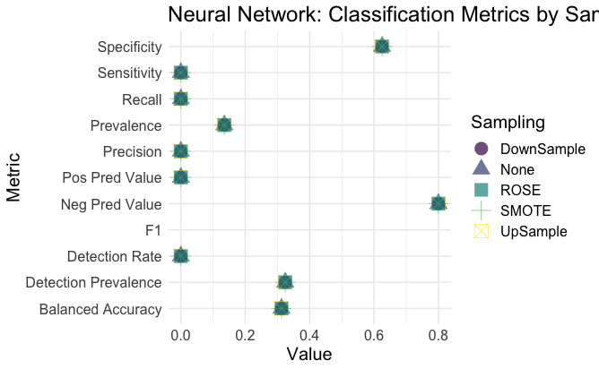

```r
#data frame for compiling results
comparisons = data.frame()
#loop through each sampling method's results and compile
for(x in 1:length(nnetResults)){

  comparisons = nnetResults[[names(samples)[x]]]$byClass%>%
    data.frame(Value = .)%>%
    rownames_to_column()%>%
    rename(Variable = rowname)%>%
    mutate(Sampling = names(samples)[x])%>%
    select(Sampling, everything())%>%
    rbind(comparisons, .)
}
#plot
comparisons%>%
  ggplot(aes(x = Variable, y = Value))+
  geom_point(aes(color = Sampling, shape = Sampling), alpha = 0.7, size = 5)+
  theme_minimal()+
  labs(title = "Neural Network: Classification Metrics by Sampling Method",
       x = "Metric")+
  coord_flip()+
  theme(text = element_text(size = 15))+
  scale_color_viridis(discrete = TRUE)
```

## Results

```r
lapply(nnetPredictions, table)
```

```
$None
         obs
pred      Control Episode
  Control      32       5
  Episode       0       0

$DownSample
         obs
pred      Control Episode
  Control      22       3
  Episode      10       2

$UpSample
         obs
pred      Control Episode
  Control      27       4
  Episode       5       1

$SMOTE
         obs
pred      Control Episode
  Control      23       4
  Episode       9       1

$ROSE
         obs
pred      Control Episode
  Control      25       5
  Episode       7       0
```

```r
do.call(rbind, nnetPredictions)%>%
  rownames_to_column()%>%
  rename(S = rowname)%>%
  separate(S, c("Sampling", "xx"), sep = "\\.")%>%
  select(-xx)%>%
  group_by(Sampling)%>%
  summarise(Overall_Accuracy = sum(pred == obs)/n())%>%
  arrange(desc(Overall_Accuracy))
```

| Sampling | Overall_Accuracy |
| --- | --- |
| None | 0.8648649 |
| UpSample | 0.7567568 |
| ROSE | 0.6756757 |
| DownSample | 0.6486486 |
| SMOTE | 0.6486486 |

```r
final_nn = comparisons%>%
  filter(Sampling == "None")%>%
  arrange(Variable)%>%
  mutate(Model = "NeuralNetwork")%>%
  select(Model, everything())
final_nn
```

| Model | Sampling | Variable | Value |
| --- | --- | --- | --- |
| NeuralNetwork | None | Balanced Accuracy | 0.3125000 |
| NeuralNetwork | None | Detection Prevalence | 0.3243243 |
| NeuralNetwork | None | Detection Rate | 0.0000000 |
| NeuralNetwork | None | F1 | NaN |
| NeuralNetwork | None | Neg Pred Value | 0.8000000 |
| NeuralNetwork | None | Pos Pred Value | 0.0000000 |
| NeuralNetwork | None | Precision | 0.0000000 |
| NeuralNetwork | None | Prevalence | 0.1351351 |
| NeuralNetwork | None | Recall | 0.0000000 |
| NeuralNetwork | None | Sensitivity | 0.0000000 |

[output cut: 1 more lines]

# Conclusion

This table ranks all of the best models for each metric:

```r
rbind(final_glm, final_RF, final_svm, final_nn)%>%
  group_by(Variable)%>%
  arrange(Variable, desc(Value))
```

| Model | Sampling | Variable | Value |
| --- | --- | --- | --- |
| LogisticRegression | SMOTE | Balanced Accuracy | 0.49687500 |
| RandomForest | None | Balanced Accuracy | 0.31250000 |
| SVM | None | Balanced Accuracy | 0.31250000 |
| NeuralNetwork | None | Balanced Accuracy | 0.31250000 |
| LogisticRegression | SMOTE | Detection Prevalence | 0.40540541 |
| RandomForest | None | Detection Prevalence | 0.32432432 |
| SVM | None | Detection Prevalence | 0.32432432 |
| NeuralNetwork | None | Detection Prevalence | 0.32432432 |
| LogisticRegression | SMOTE | Detection Rate | 0.05405405 |
| RandomForest | None | Detection Rate | 0.00000000 |

[output cut: 34 more lines]

The overall accuracy is 83% for logistic regression, 81% for random forest, 86% for the SVM, and 86% for neural network